# Accident Analysis

蔡宇媗(組別：馬路如虎口 獅子大開口)

2022-12-13

下載套件(下載一次即可) here套件可允許載入含中文名稱的資料，讀取路徑與此Rmd檔案為同一資料夾 aTSA、TSA為時間序列套件，處理發生時間用

```r
#install.packages('here')
#install.packages('aTSA')
#install.packages('TSA')
```

資料下載：都是清洗過後的資料，包含： 1. 雙方性別 2. 雙方交通工具：按照法律規定分為汽車、機慢車、行人、職業駕駛(雖已廢除，但小組想驗證是否這點已經沒有影響力) 3. 雙方經濟狀況：分為較佳(富裕及小康)、普通、較差(清寒及貧窮)三個類別 4. 請求人身分：法定上配偶、子女與父母有慰撫金的請求權 5. 正式資料：包含日期、鑑定會給予責任(分為被告責任較重、被告同等責任、被告責任較輕三個類別)、請求金額與前面經檢定為顯著且與其他變數獨立的自變數

```r
library(here)
CSV1<-here::here("gender.csv") #性別
gender<-read.csv(CSV1,header=TRUE, sep=",",fileEncoding = 'BIG5')
head(gender)
```

```
##   被告性別 原告性別 慰撫金金額
## 1        1        0    1000000
## 2        1        0    1100000
## 3        1        0    1100000
## 4        1        0     900000
## 5        1        1     600000
## 6        1        0     600000
```

```r
CSV2<-here::here("transportation.csv") #交通工具
trans<-read.csv(CSV2,header=TRUE, sep=",",fileEncoding = 'BIG5')
head(trans)
```

```
##   被告交通工具 被告汽車 被告機慢車 被告職業駕駛 原告交通工具 原告汽車
## 1            2        0          1            0            2        0
## 2            2        0          1            0            2        0
## 3            2        0          1            0            2        0
## 4            2        0          1            0            2        0
## 5            2        0          1            0            2        0
## 6            2        0          1            0            2        0
##   原告機慢車 原告行人 慰撫金金額
## 1          1        0    1000000
## 2          1        0    1100000
## 3          1        0    1100000
## 4          1        0     900000
## 5          1        0     600000
## 6          1        0     600000
```

```r
CSV3<-here::here("socialstatus.csv") #經濟狀況
socialstatus<-read.csv(CSV3,header=TRUE, sep=",",fileEncoding = 'BIG5')
head(socialstatus)
```

```
##   被告經濟狀況 被告較佳 被告中等 被告較差 原告經濟狀況 原告較佳 原告中等
## 1            4        0        0        1            4        0        0
## 2            4        0        0        1            3        0        1
## 3            4        0        0        1            3        0        1
## 4            3        0        1        0            2        1        0
## 5            3        0        1        0            2        1        0
## 6            3        0        1        0            2        1        0
##   原告較差 原被告差距 慰撫金金額
## 1        1          0    1000000
## 2        0         -1    1100000
## 3        0         -1    1100000
## 4        0         -1     900000
## 5        0         -1     600000
## 6        0         -1     600000
```

```r
CSV4<-here::here("people.csv") #請求人身分
identity<-read.csv(CSV4,header=TRUE, sep=",",fileEncoding = 'BIG5')
head(identity)
```

```
##   請求權人身分 請求權人子女 請求權人父母 請求權人人數 慰撫金金額
## 1            4            0            1            3    1000000
## 2            3            1            0            3    1100000
## 3            3            1            0            3    1100000
## 4            2            0            0            3     900000
## 5            3            1            0            3     600000
## 6            3            1            0            3     600000
```

```r
CSV5<-here::here("date.csv") #正式資料
date<-read.csv(CSV5,header=TRUE, sep=",",fileEncoding = 'BIG5')
head(date)
```

```
##    發生日期 慰撫金金額 請求慰撫金金額 鑑定會給予被告責任 被告責任較重
## 1 2015/9/10    1000000        1500000                  2            1
## 2 2015/9/10    1100000        1500000                  2            1
## 3 2015/9/10    1100000        1500000                  2            1
## 4 2016/2/23     900000        2000000                  5            0
## 5 2016/2/23     600000        2000000                  5            0
## 6 2016/2/23     600000        2000000                  5            0
##   被告責任較輕 鑑定會給予原告責任 原告汽車 原告機慢車 原告行人 請求權人人數
## 1            0                  4        0          1        0            3
## 2            0                  4        0          1        0            3
## 3            0                  4        0          1        0            3
## 4            1                  1        0          1        0            3
## 5            1                  1        0          1        0            3
## 6            1                  1        0          1        0            3
```

```r
money<-log10(gender$慰撫金) #log10轉換慰撫金數值
#線性迴歸
glm1<-glm(money~gender$被告性別,family=gaussian(),data=gender)
summary(glm1)
```

```
##
## Call:
## glm(formula = money ~ gender$被告性別, family = gaussian(),
##     data = gender)
##
## Deviance Residuals:
##      Min        1Q    Median        3Q       Max
## -0.76942  -0.16736  -0.01719   0.18693   0.70770
##
## Coefficients:
##                 Estimate Std. Error t value Pr(>|t|)
## (Intercept)      5.76942    0.07121  81.025  < 2e-16 ***
## gender$被告性別  0.24777    0.08256   3.001  0.00359 **
## ---
## Signif. codes:  0 '***' 0.001 '**' 0.01 '*' 0.05 '.' 0.1 ' ' 1
##
## (Dispersion parameter for gaussian family taken to be 0.1064739)
##
##     Null deviance: 9.4769  on 81  degrees of freedom
## Residual deviance: 8.5179  on 80  degrees of freedom
## AIC: 53.013
##
## Number of Fisher Scoring iterations: 2
```

```r
glm11<-glm(money~gender$原告性別,family=gaussian(),data=gender)
summary(glm11)
```

```
##
## Call:
## glm(formula = money ~ gender$原告性別, family = gaussian(),
##     data = gender)
##
## Deviance Residuals:
##      Min        1Q    Median        3Q       Max
## -0.96316  -0.16353   0.03684   0.23441   0.53544
##
## Coefficients:
##                 Estimate Std. Error t value Pr(>|t|)
## (Intercept)      5.96316    0.05072 117.566   <2e-16 ***
## gender$原告性別 -0.02148    0.07655  -0.281     0.78
## ---
## Signif. codes:  0 '***' 0.001 '**' 0.01 '*' 0.05 '.' 0.1 ' ' 1
##
## (Dispersion parameter for gaussian family taken to be 0.118345)
##
##     Null deviance: 9.4769  on 81  degrees of freedom
## Residual deviance: 9.4676  on 80  degrees of freedom
## AIC: 61.681
##
## Number of Fisher Scoring iterations: 2
```

```r
#交通工具差異
glm2<-glm(money~trans$被告職業駕駛+
               trans$被告機慢車+trans$被告汽車+trans$原告行人+
               trans$原告機慢車+trans$原告汽車,family=gaussian(),data=trans)
summary(glm2)
```

```
##
## Call:
## glm(formula = money ~ trans$被告職業駕駛 + trans$被告機慢車 +
##     trans$被告汽車 + trans$原告行人 + trans$原告機慢車 +
##     trans$原告汽車, family = gaussian(), data = trans)
##
## Deviance Residuals:
##     Min       1Q   Median       3Q      Max
## -0.7718  -0.2425   0.0644   0.2282   0.5292
##
## Coefficients:
##                    Estimate Std. Error t value Pr(>|t|)
## (Intercept)          6.7185     0.2649  25.361  < 2e-16 ***
## trans$被告職業駕駛  -0.0776     0.1451  -0.535  0.59443
## trans$被告機慢車    -0.2414     0.1447  -1.668  0.09939 .
## trans$被告汽車       0.1324     0.1509   0.877  0.38310
## trans$原告行人      -0.7736     0.2423  -3.192  0.00206 **
## trans$原告機慢車    -0.7053     0.2319  -3.042  0.00324 **
## trans$原告汽車      -0.7210     0.2998  -2.405  0.01865 *
## ---
## Signif. codes:  0 '***' 0.001 '**' 0.01 '*' 0.05 '.' 0.1 ' ' 1
##
## (Dispersion parameter for gaussian family taken to be 0.09850264)
##
##     Null deviance: 9.4769  on 81  degrees of freedom
## Residual deviance: 7.3877  on 75  degrees of freedom
## AIC: 51.34
##
## Number of Fisher Scoring iterations: 2
```

```r
glm3<-glm(money~
            socialstatus$被告較佳+socialstatus$被告中等
         +socialstatus$被告較差+socialstatus$原告較佳+
            socialstatus$原告中等+socialstatus$原告較差
,family=gaussian(),data=socialstatus)
summary(glm3)
```

```
##
## Call:
## glm(formula = money ~ socialstatus$被告較佳 + socialstatus$被告中等 +
##     socialstatus$被告較差 + socialstatus$原告較佳 + socialstatus$原告中等 +
##     socialstatus$原告較差, family = gaussian(), data = socialstatus)
##
## Deviance Residuals:
##      Min        1Q    Median        3Q       Max
## -0.91421  -0.09888  -0.00301   0.13582   0.56291
##
## Coefficients:
##                       Estimate Std. Error t value Pr(>|t|)
## (Intercept)            5.91421    0.06485  91.196  < 2e-16 ***
## socialstatus$被告較佳  0.17580    0.20912   0.841  0.40321
## socialstatus$被告中等  0.51072    0.16562   3.084  0.00286 **
## socialstatus$被告較差  0.54439    0.19771   2.754  0.00739 **
## socialstatus$原告較佳 -0.24583    0.14741  -1.668  0.09956 .
## socialstatus$原告中等 -0.42296    0.18503  -2.286  0.02508 *
## socialstatus$原告較差 -0.45860    0.38528  -1.190  0.23767
## ---
## Signif. codes:  0 '***' 0.001 '**' 0.01 '*' 0.05 '.' 0.1 ' ' 1
##
## (Dispersion parameter for gaussian family taken to be 0.1051445)
##
##     Null deviance: 9.4769  on 81  degrees of freedom
## Residual deviance: 7.8858  on 75  degrees of freedom
## AIC: 56.691
##
## Number of Fisher Scoring iterations: 2
```

```r
glm31<-glm(money~socialstatus$原被告差距,family=gaussian(),data=socialstatus)
summary(glm31)
```

```
##
## Call:
## glm(formula = money ~ socialstatus$原被告差距, family = gaussian(),
##     data = socialstatus)
##
## Deviance Residuals:
##      Min        1Q    Median        3Q       Max
## -0.86556  -0.09972  -0.00691   0.16918   0.61156
##
## Coefficients:
##                          Estimate Std. Error t value Pr(>|t|)
## (Intercept)              6.006913   0.047059 127.648   <2e-16 ***
## socialstatus$原被告差距 -0.001428   0.000773  -1.847   0.0684 .
## ---
## Signif. codes:  0 '***' 0.001 '**' 0.01 '*' 0.05 '.' 0.1 ' ' 1
##
## (Dispersion parameter for gaussian family taken to be 0.1136165)
##
##     Null deviance: 9.4769  on 81  degrees of freedom
## Residual deviance: 9.0893  on 80  degrees of freedom
## AIC: 58.337
##
## Number of Fisher Scoring iterations: 2
```

4. 請求人身分(不論是哪種身分，皆顯著)

```r
chisq.test(identity$請求權人子女,money)
```

```
##
##  Pearson's Chi-squared test
##
## data:  identity$請求權人子女 and money
## X-squared = 33.816, df = 14, p-value = 0.002194
```

```r
chisq.test(identity$請求權人父母,money)
```

```
##
##  Pearson's Chi-squared test
##
## data:  identity$請求權人父母 and money
## X-squared = 41.067, df = 14, p-value = 0.0001736
```

```r
glm4<-glm(money~identity$請求權人子女,family=gaussian(),data=identity)
summary(glm4)
```

```
##
## Call:
## glm(formula = money ~ identity$請求權人子女, family = gaussian(),
##     data = identity)
##
## Deviance Residuals:
##      Min        1Q    Median        3Q       Max
## -1.13159  -0.13159   0.09273   0.16944   0.43952
##
## Coefficients:
##                       Estimate Std. Error t value Pr(>|t|)
## (Intercept)            6.13159    0.06025 101.766  < 2e-16 ***
## identity$請求權人子女 -0.27008    0.07425  -3.638 0.000486 ***
## ---
## Signif. codes:  0 '***' 0.001 '**' 0.01 '*' 0.05 '.' 0.1 ' ' 1
##
## (Dispersion parameter for gaussian family taken to be 0.1016489)
##
##     Null deviance: 9.4769  on 81  degrees of freedom
## Residual deviance: 8.1319  on 80  degrees of freedom
## AIC: 49.21
##
## Number of Fisher Scoring iterations: 2
```

```r
glm41<-glm(money~identity$請求權人父母,family=gaussian(),data=identity)
summary(glm41) #都顯著
```

```
##
## Call:
## glm(formula = money ~ identity$請求權人父母, family = gaussian(),
##     data = identity)
##
## Deviance Residuals:
##      Min        1Q    Median        3Q       Max
## -0.87993  -0.21615   0.07431   0.19925   0.42110
##
## Coefficients:
##                       Estimate Std. Error t value Pr(>|t|)
## (Intercept)            5.87993    0.03925 149.797  < 2e-16 ***
## identity$請求權人父母  0.33622    0.08378   4.013 0.000134 ***
## ---
## Signif. codes:  0 '***' 0.001 '**' 0.01 '*' 0.05 '.' 0.1 ' ' 1
##
## (Dispersion parameter for gaussian family taken to be 0.09860953)
##
##     Null deviance: 9.4769  on 81  degrees of freedom
## Residual deviance: 7.8888  on 80  degrees of freedom
## AIC: 46.721
##
## Number of Fisher Scoring iterations: 2
```

```r
glm42<-glm(money~identity$請求權人人數,family=gaussian(),data=identity)
summary(glm42)
```

```
##
## Call:
## glm(formula = money ~ identity$請求權人人數, family = gaussian(),
##     data = identity)
##
## Deviance Residuals:
##      Min        1Q    Median        3Q       Max
## -0.73047  -0.10910   0.04285   0.21098   0.43596
##
## Coefficients:
##                       Estimate Std. Error t value Pr(>|t|)
## (Intercept)            6.56264    0.08015  81.875  < 2e-16 ***
## identity$請求權人人數 -0.16643    0.02051  -8.113 4.85e-12 ***
## ---
## Signif. codes:  0 '***' 0.001 '**' 0.01 '*' 0.05 '.' 0.1 ' ' 1
##
## (Dispersion parameter for gaussian family taken to be 0.0649868)
##
##     Null deviance: 9.4769  on 81  degrees of freedom
## Residual deviance: 5.1989  on 80  degrees of freedom
## AIC: 12.528
##
## Number of Fisher Scoring iterations: 2
```

5. 正式資料： 先使用單根檢定(Unit Root Test)確認判決金額沒有隨著事故發生時間產生變高或是變低的趨勢

考量到變數間因果關係難以釐清，且已盡量使變數間為獨立(互不影響)，所以不加入交互作用項(交互作用項：例如責任*職業駕駛兩個以上變數乘積的變項)

```r
library(aTSA)
library(TSA)
money<-log10(date$慰撫金金額)
adf.test(money) #通過-沒有時間效應
```

```
## Augmented Dickey-Fuller Test
## alternative: stationary
##
## Type 1: no drift no trend
##      lag     ADF p.value
## [1,]   0 0.01817   0.647
## [2,]   1 0.00599   0.643
## [3,]   2 0.01415   0.646
## [4,]   3 0.04961   0.656
## Type 2: with drift no trend
##      lag   ADF p.value
## [1,]   0 -3.49  0.0121
## [2,]   1 -3.75  0.0100
## [3,]   2 -3.91  0.0100
## [4,]   3 -4.37  0.0100
## Type 3: with drift and trend
##      lag   ADF p.value
## [1,]   0 -3.52  0.0454
## [2,]   1 -3.79  0.0236
## [3,]   2 -3.95  0.0164
## [4,]   3 -4.41  0.0100
## ----
## Note: in fact, p.value = 0.01 means p.value <= 0.01
```

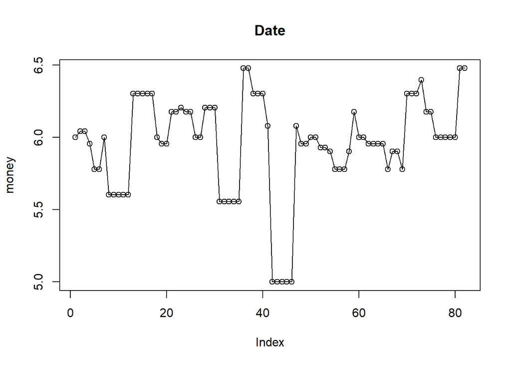

```r
#畫圖
plot(money,type="o")
title("Date")
```

```r
#線性迴歸一
askmoney<-log10(date$請求慰撫金金額)
linearglm<-glm(money~date$被告責任較重+date$被告責任較輕+askmoney,family=gaussian(),data=date)
summary(linearglm)
```

```
##
## Call:
## glm(formula = money ~ date$被告責任較重 + date$被告責任較輕 +
##     askmoney, family = gaussian(), data = date)
##
## Deviance Residuals:
##      Min        1Q    Median        3Q       Max
## -0.43934  -0.08028   0.03392   0.11215   0.68653
##
## Coefficients:
##                   Estimate Std. Error t value Pr(>|t|)
## (Intercept)        1.01206    0.53240   1.901    0.061 .
## date$被告責任較重 -0.02457    0.06103  -0.403    0.688
## date$被告責任較輕 -0.09833    0.06972  -1.410    0.162
## askmoney           0.81281    0.08612   9.438 1.53e-14 ***
## ---
## Signif. codes:  0 '***' 0.001 '**' 0.01 '*' 0.05 '.' 0.1 ' ' 1
##
## (Dispersion parameter for gaussian family taken to be 0.05372524)
##
##     Null deviance: 9.4769  on 81  degrees of freedom
## Residual deviance: 4.1906  on 78  degrees of freedom
## AIC: -1.1525
##
## Number of Fisher Scoring iterations: 2
```

```r
#因為資料沒有同等責任
```

```r
#線性迴歸二
linearglm2<-glm(money~date$被告責任較重+date$被告責任較輕+date$請求權人人數,family=gaussian(),data=date)
summary(linearglm2)
```

```
##
## Call:
## glm(formula = money ~ date$被告責任較重 + date$被告責任較輕 +
##     date$請求權人人數, family = gaussian(), data = date)
##
## Deviance Residuals:
##      Min        1Q    Median        3Q       Max
## -0.64877  -0.13263   0.02243   0.17158   0.42037
##
## Coefficients:
##                   Estimate Std. Error t value Pr(>|t|)
## (Intercept)        6.59850    0.08168  80.785  < 2e-16 ***
## date$被告責任較重 -0.12110    0.06506  -1.862   0.0664 .
## date$被告責任較輕 -0.02452    0.07771  -0.316   0.7532
## date$請求權人人數 -0.16573    0.02092  -7.922 1.33e-11 ***
## ---
## Signif. codes:  0 '***' 0.001 '**' 0.01 '*' 0.05 '.' 0.1 ' ' 1
##
## (Dispersion parameter for gaussian family taken to be 0.06376836)
##
##     Null deviance: 9.4769  on 81  degrees of freedom
## Residual deviance: 4.9739  on 78  degrees of freedom
## AIC: 12.9
##
## Number of Fisher Scoring iterations: 2
```